# Efficacy of Prosper Score and Prosper Rating for Predicting Loan Outcome

by Olga Timofeeva

## Investigation Overview

In this investigation, I wanted to look at the characteristics of Prosper Loans that could be used to predict a loan outcome (loan status).

Main focus was on the Prosper metrics Prosper Score and Prosper Rating (Alpha), as well as some other variables that can directly or indirectly via Prosper Score or Prosper Rating influence loan outcome (loan status)

## Dataset Overview

The data consisted of loans and attributes of approximately approximately 113,936 loans. The dataset was last updated on 03/11/2014.

However, the data set was filtered and cleaned for this project to select only loans where Prosper Score is available (past July 2009).

The filtered data set for this project contains 77557 loans.

## Loan Status Distribution

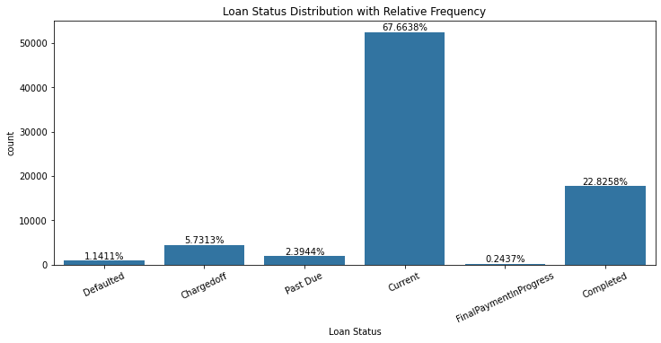

```python
# take a look at loan status distribution over the data set
countplot_categorical_frequencies(loans_except_cancelled, 'LoanStatusSimplified', [12,5],
                                  'Loan Status Distribution with Relative Frequency', 25,
                                 'Loan Status');
```

## Borrower Income Range Distribution

This plot demonstrates that most of the loans have income range greater than \$25,000, and only a very small proportion of loans would not have income.

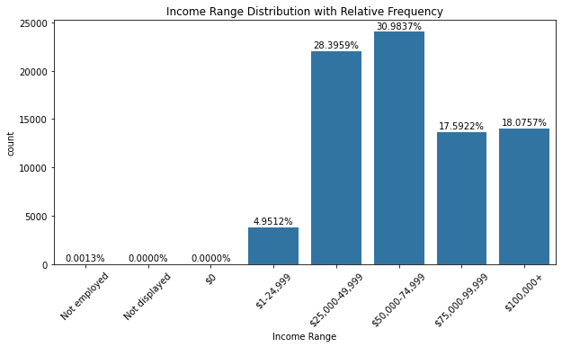

```python
# take a quick glance at income range distribution
# this variable could be a yearly estimate as it contradicts monthly stated income
countplot_categorical_frequencies(loans_except_cancelled, 'IncomeRange', [10,5],
                                  'Income Range Distribution with Relative Frequency',
                                  45, 'Income Range');
```

## Loan Category Distribution

This indicates some client on-boarding and data quality issues, as loan category is potentially one of the indicators driving loan outcome.

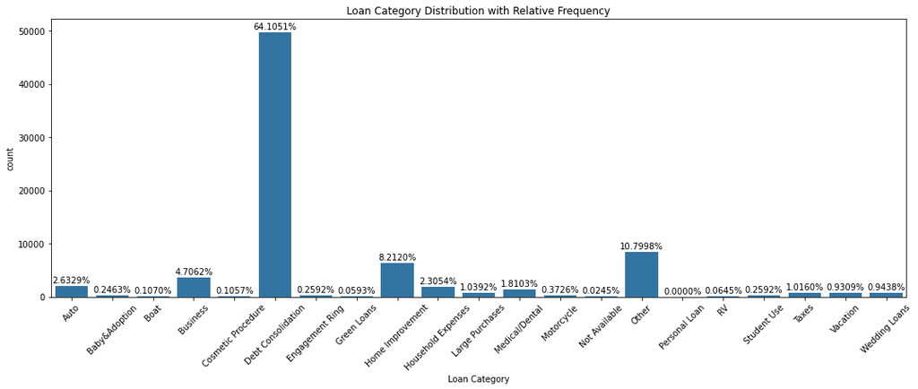

```python
# plot how loans are didtributed across categories
countplot_categorical_frequencies(loans_except_cancelled, 'LoanCategory', [18,6],
                                  'Loan Category Distribution with Relative Frequency',
                                  45, 'Loan Category')
```

## Borrower Occupation Distribution

Surprisingly borrower occupation has many 'Other' values for the `Occupation` variable. Loans are not equally distributed among occupations. It will be used to revisit this distribution over loan status breakdown to see if there are some occupations that outperform others.

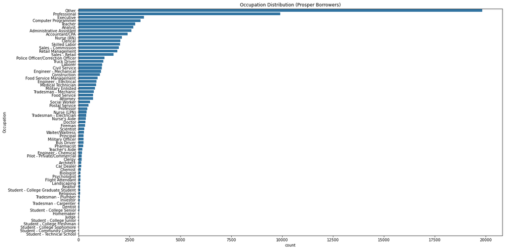

```python
# count plot for borrower occupation
occupation_counts = loans_except_cancelled['Occupation'].value_counts()
occupation_order = occupation_counts.index
fig, ax = plt.subplots(figsize = [20,11])

default_color = sb.color_palette()[0]
sb.countplot(data = loans_except_cancelled, y = 'Occupation', color = default_color, order=occupation_order, ax = ax);
plt.title('Occupation Distribution (Prosper Borrowers)');
#plt.xticks(rotation=65);
```

## Borrower State Distribution

This plot reveals that loans are not equally distributed across the state. It will be interesting to investigate if some states have bigger proportion of defaulting or completed loans than others.

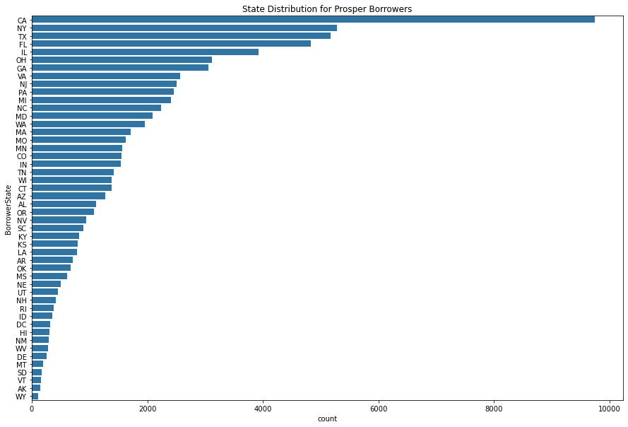

```python
state_counts = loans_except_cancelled['BorrowerState'].value_counts()
state_order = state_counts.index

fig, ax = plt.subplots(figsize = [15,10])

default_color = sb.color_palette()[0]
sb.countplot(data = loans_except_cancelled, y = 'BorrowerState', color = default_color, order=state_order, ax = ax);
plt.title('State Distribution for Prosper Borrowers');
#plt.xticks(rotation=15);
```

## Distributions of Other Loan Categorical Variables

Slides below will demonstrate distributions for the following variables

- EmploymentStatus
- ProsperRating (Alpha)
- ProsperRating (numeric)
- ProsperScore (will be used as categorical variable for most vizualisations)

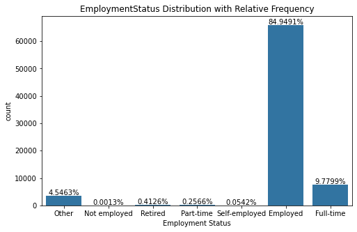

```python
# Employment Status Distribution
countplot_categorical_frequencies(loans_except_cancelled,
                                  'EmploymentStatus', [8,5],
                                  'EmploymentStatus Distribution with Relative Frequency',
                                  0, 'Employment Status')
```

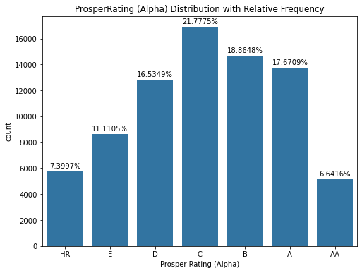

```python
# 'ProsperRating (Alpha)' countplot
countplot_categorical_frequencies(loans_except_cancelled, 'ProsperRating (Alpha)', [8,6],
                                  'ProsperRating (Alpha) Distribution with Relative Frequency',
                                  0, 'Prosper Rating (Alpha)')
```

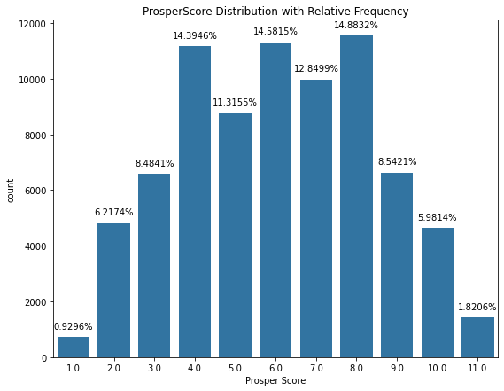

```python
# Prosper Score distribution
countplot_categorical_frequencies(loans_except_cancelled, 'ProsperScore', [9,7],
                                  'ProsperScore Distribution with Relative Frequency',
                                  0, 'Prosper Score')
```

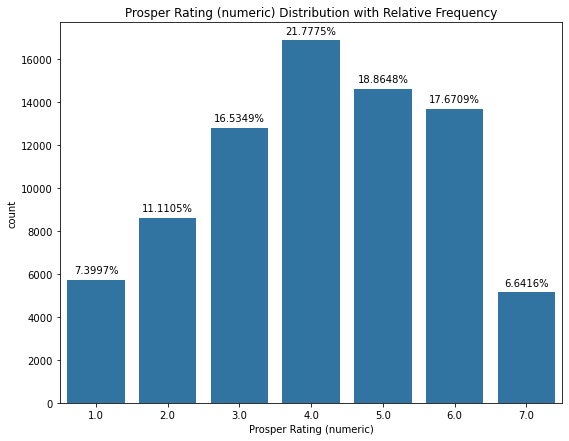

```python
# ProsperRating (numeric) distribution
countplot_categorical_frequencies(loans_except_cancelled, 'ProsperRating (numeric)', [9,7],
                                  'Prosper Rating (numeric) Distribution with Relative Frequency',
                                  0, 'Prosper Rating (numeric)')
```

> Loan Categorical Variables Distribution (cont.):
> - vast majority of Prosper borrowers are employed, and their income is verifiable.
> - Loan rating distribution follows normal distribution curve peaking at C rating
> - ProsperScore distribution looks like a bimodal distribution with peaks at 4.0 and 8.0 score
> - ProsperRating (numeric) distribution looks like a normal distribution with a peak at 4

## Distribution of Loan Numeric Variables

### Bank Card Utilization, Delinquencies, and Borrower Rate Distribution

- BankcardUtilization
- DelinquenciesLast7Years
- BorrowerRate

Observations:

> `Borrower Rate` and `Bank Card Utilization` show density curve of a bell shape which suggests these variables are normally distributed

> `Delinquencies Last 7 Years` however is largely skewed to the right which would be expected from a lender not to give loans to borrowers who had many delinquencies in the past.

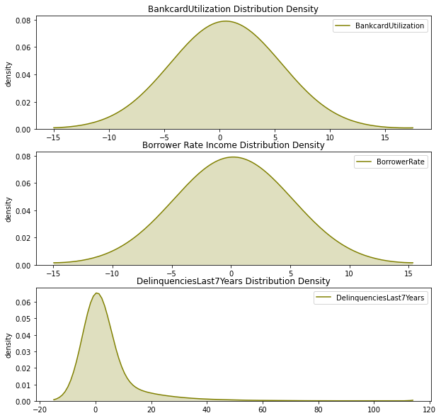

```python
# Plot Bank Card Utilization, BorrowerRate, DelinquenciesLast7Years, Distributions
# Set a larger figure size for subplots
plt.figure(figsize = [10, 10])

# 1 row, 2 cols, subplot 1
plt.subplot(3, 1, 1)
sb.kdeplot(loans_except_cancelled['BankcardUtilization'],  shade=True, bw=5, color="olive");
plt.ylabel('density')
plt.title('BankcardUtilization Distribution Density')

plt.subplot(3, 1, 3) # 1 row, 2 cols, subplot 2
sb.kdeplot(loans_except_cancelled['DelinquenciesLast7Years'], shade=True, bw=5, color="olive");
plt.ylabel('density')
plt.title('DelinquenciesLast7Years Distribution Density');

plt.subplot(3, 1, 2)
sb.kdeplot(loans_except_cancelled['BorrowerRate'], shade=True, bw=5, color="olive");
plt.ylabel('density')
plt.title('Borrower Rate Income Distribution Density');
```

### Stated Monthly Income Distribution

This variable is suspected to be one of the major factors influencing a loan outcome.

Stated monthly income is highly skewed to the right, and it's looks like there are outliers around 400,000+ mark. These outliers with abnormally high income which is most probably data quality issue when income was incorrectly interred into Prosper system.

Plotted on a logarithmic scale, the distribution of stated monthly income takes on a normal distribution shape.

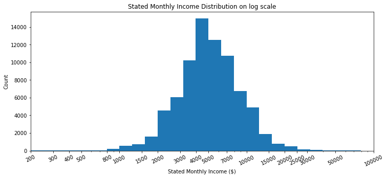

```python
# zoom in on monthly stated income
binsize = 5000
bins = 10 ** np.arange(-1, 6 + 0.1, 0.1)

plt.figure(figsize=[12, 5])

# Generate the x-ticks you want to apply
ticks = [100, 200, 300, 400, 500, 800, 1000, 1500, 2000, 3000, 4000,
         5000, 7000, 10000, 15000, 20000, 25000, 30000, 50000, 100000]
# Convert ticks into string values, to be displaye dlong the x-axis
labels = ['{}'.format(v) for v in ticks]

plt.hist(data = loans_except_cancelled, x = 'StatedMonthlyIncome', bins = bins)
plt.xscale('log')
plt.xlabel('Stated Monthly Income ($)')
plt.ylabel('Count')
# Apply x-ticks
plt.xticks(ticks, labels, rotation=25)
plt.xlim([200, 100000])
plt.title('Stated Monthly Income Distribution on log scale')
plt.show();
```

### Debt to Income Ratio Distribution

Next, debt-to-income ratio will be investigated, starting with KDE and violin plot to eyeball this variable kernel density distribution.

We can see similar pattern as with stated monthly income : the variable is highly skewed to the right and there are outliers at the end of the right tail.

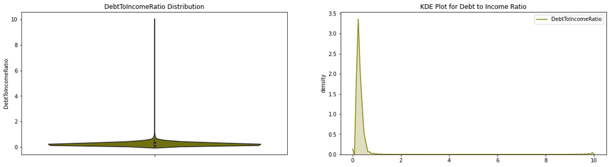

```python
# plot DebtToIncomeRatio Distribution - KDE and vilolin plot side by side
plt.figure(figsize = [20, 5])

plt.subplot(1, 2, 1)
ax = sb.violinplot(y=loans_except_cancelled['DebtToIncomeRatio'], showfliers = True, color="olive")
plt.title('DebtToIncomeRatio Distribution');

plt.subplot(1, 2, 2) # 1 row, 2 cols, subplot 2
sb.kdeplot(loans_except_cancelled['DebtToIncomeRatio'], shade=True, bw=0.0005, color="olive");
plt.ylabel('density')
plt.title('KDE Plot for Debt to Income Ratio');
```

#### Debt-to-income ratio Distribution on log scale

Debt-to-income ratio log normal distribution still looks highly skewed to the right, with two peaks around 1 and 11 values. Log scale might not be appropriate for debt-to-income ratio, hence I will not use scale transformations for this variable going forward.

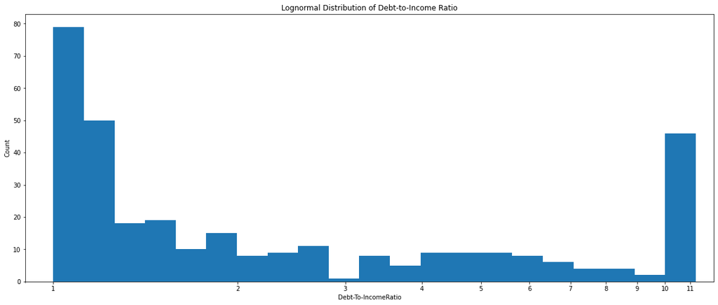

```python
# plot lognormal Distribution of Debt-to-Income Ratio
binsize = 0.05
bins = 10 ** np.arange(0, 10.01 +binsize, binsize)

# Generate the x-ticks you want to apply
ticks = [1,2,3,4,5,6,7,8,9,10,11]
# Convert ticks into string values, to be displaye dlong the x-axis
labels = ['{}'.format(v) for v in ticks]


plt.figure(figsize=[20, 8])
plt.hist(data = loans_except_cancelled, x = 'DebtToIncomeRatio', bins = bins)
plt.xscale('log')
plt.xlabel('Debt-To-IncomeRatio')
plt.xticks(ticks, labels)
plt.xlim([0.9, 12])
plt.ylabel('Count')
plt.title('Lognormal Distribution of Debt-to-Income Ratio')
plt.show()
```

### Loan Original Amount Distribution

This probably represent that loans have standard amounts based on the information provided by a borrower.

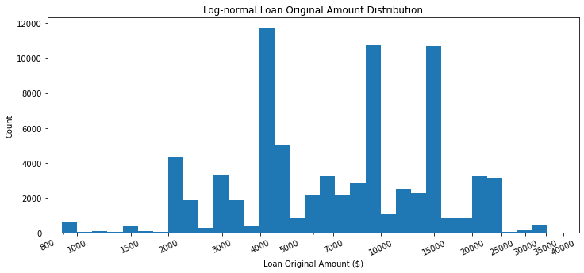

```python
# plot Log-normal Loan Original Amount Distribution
bins = 10 ** np.arange(-1, 6 + 0.05, 0.05)

plt.figure(figsize=[12, 5])

# Generate the x-ticks you want to apply
ticks = [800, 1000, 1500, 2000, 3000, 4000,
         5000, 7000, 10000, 15000, 20000, 25000, 30000, 35000, 40000]
# Convert ticks into string values, to be displaye dlong the x-axis
labels = ['{}'.format(v) for v in ticks]

plt.hist(data = loans_except_cancelled, x = 'LoanOriginalAmount', bins = bins)
plt.xscale('log')
plt.xlabel('Loan Original Amount ($)')
# Apply x-ticks
plt.xticks(ticks, labels, rotation=25)
plt.xlim([800, 45000])
plt.ylabel('Count')
plt.title('Log-normal Loan Original Amount Distribution');
plt.show();
```

## Correlation Among Loan Numerical Features and Prosper Score

As we can see Borrower Rate is correlated to `Prosper Score`. Thus I will be investigating only `Borrower Rate` further.

`Prosper Rating (numeric)` is also highly correlated to `Prosper Score` so that prosper score system seems to be consistent for these two variables.

Surprisingly `ProsperScore` does not show strong correlation with these variables:

- `BankCardUtilization`
- `StatedMonthlyIncome`
- `LoanOriginalAmount`
- `DelinquenciesLast7Years`

Nevertheless, `ProsperScore` negatively correlated with `BorrowerRate` as expected: the higher the rating, the lower the rate (as expected).

Interestingly, `StatedMonthlyIncome` does not have strong correlation with `DebtToIncomeRatio`.

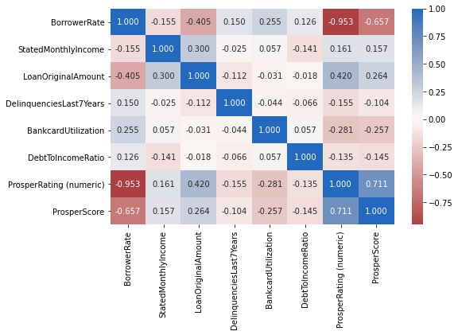

```python
# correlation plot
plt.figure(figsize = [8, 5])
sb.heatmap(loans_except_cancelled[numeric_vars].corr(), annot = True, fmt = '.3f',
           cmap = 'vlag_r', center = 0)
plt.show()
```

## Loan Status Relationship with Loan Categorical Features

### Prosper Rating, Prosper Score, and Employment Status vs Loan Status

Now we will plot categorical variables distribution over loan status for:

- ProsperRating (Alpha)
- Prosper Score - will be used as categorical variable in this plot
- Employment Status
- most loans were given to the borrowers with verifiable income who are employed. However, there is data quality issue as there is a large proportion of loans with no clear distinction of employment status (`EmploymentStatus` = `Other`).
- Loans with `ProsperScore` equal or greater than 8.0 or Prosper Rating Alpha higher than C are more likely to be completed.

This plot suggests that Prosper rating and scoring systems are working rather well for making decision on a loan and predict defaults. Hence, Prosper scoring system looks reliable.

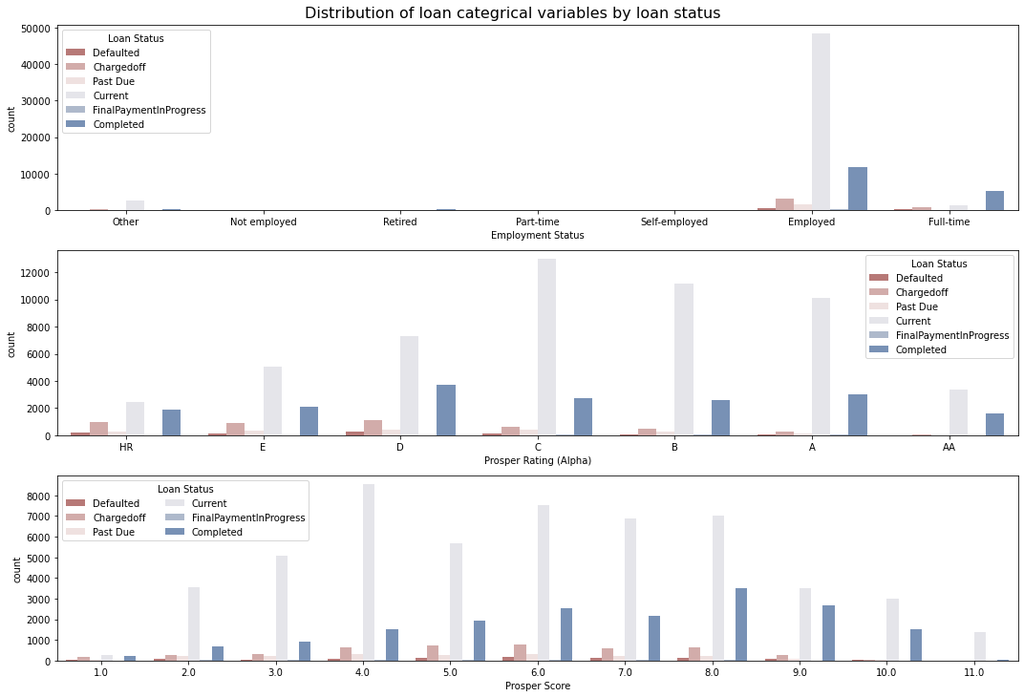

```python
# plot for Employment Status, Prosper Score and Prosper Rating
#categorical variables vs LoanStatusSimplified
fig, ax = plt.subplots(nrows=3, figsize = [15,10])
fig.suptitle('Distribution of loan categrical variables by loan status', y=1.01, fontsize=16)
default_color = sb.color_palette()[0]

#sb.countplot(data = loans_except_cancelled, x = 'IncomeVerifiable', palette = 'vlag_r', ax = ax[0], hue= 'LoanStatusSimplified')
#sb.countplot(data = loans_except_cancelled, x = 'IsBorrowerHomeowner', palette = 'vlag_r', ax = ax[2], hue= 'LoanStatusSimplified')
#sb.countplot(data = loans_except_cancelled, x = 'TermYears', palette = 'vlag_r', ax = ax[3], hue= 'LoanStatusSimplified')
sb.countplot(data = loans_except_cancelled, x = 'EmploymentStatus',
             palette = 'vlag_r', ax = ax[0], hue= 'LoanStatusSimplified')
ax[0].legend(loc = 'upper left', ncol = 1, title = 'Loan Status')
ax[0].set_xlabel('Employment Status')

sb.countplot(data = loans_except_cancelled, x = 'ProsperRating (Alpha)',
             palette = 'vlag_r', ax = ax[1], hue= 'LoanStatusSimplified')
ax[1].legend(loc = 'upper right', ncol = 1, title = 'Loan Status')
ax[1].set_xlabel('Prosper Rating (Alpha)')

sb.countplot(data = loans_except_cancelled, x = 'ProsperScore',
             palette = 'vlag_r', ax = ax[2], hue= 'LoanStatusSimplified')
ax[2].legend(loc = 'upper left', ncol = 2, title = 'Loan Status')
ax[2].set_xlabel('Prosper Score')

plt.tight_layout()
plt.show();
```

### Borrower Occupation Relationship with Loan Outcome

> This plot shows that some occupations outperform others. For example, professionals, executives, teachers, accountants, analysts look as more reliable occupations for taking a loan than others. This could be related to the nature of the job (seasonal/contractual vs permanent or government subsidized).

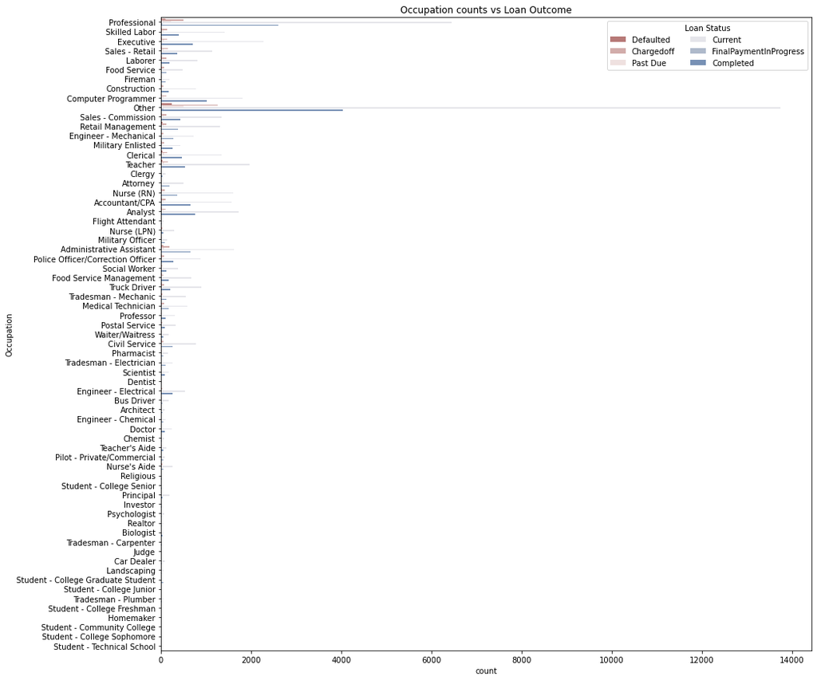

```python
# countplot for occupation vs loan outcome
fig, ax = plt.subplots(figsize = [15,15])

default_color = sb.color_palette()[0]
sb.countplot(data = loans_except_cancelled, y = 'Occupation',
             hue='LoanStatusSimplified', palette='vlag_r', ax = ax);
plt.legend(loc = 'upper right', ncol = 2, title = 'Loan Status')
plt.title('Occupation counts vs Loan Outcome');
```

### Borrower State Relationship with Loan Outcome

> Loans are not equally distributed among the states with some states have better loan outcome than others. This could be related to the economic reasons such as seasonality and some occupations concentrated in particular states. Thus, loan outcome can correlate to the state and the occupation of the borrower.

> For example, California has the largest proportion of loans, but it is possible to estimate by the plot that proportion of defaulted/charged-off/past due loans for this state is smaller than for other states.

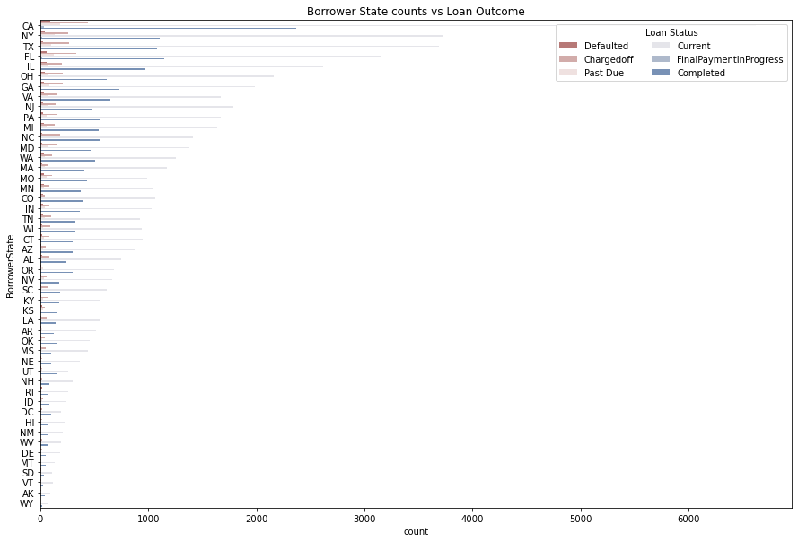

```python
# count plot for borrower state vs loan status
fig, ax = plt.subplots(figsize = [15,10])

default_color = sb.color_palette()[0]
sb.countplot(data = loans_except_cancelled,
             y = 'BorrowerState', hue='LoanStatusSimplified',
             palette='vlag_r', ax = ax, order=state_order);
plt.legend(loc = 'upper right', ncol = 2, title = 'Loan Status')
plt.title('Borrower State counts vs Loan Outcome');
```

### Loan Category Interaction with Loan Outcome

Loan category looks related to the outcome of the loan, with 'Debt Consolidation' as top category for total loans.

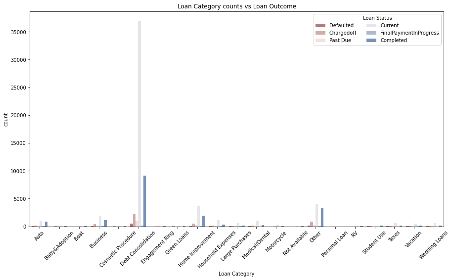

```python
plt.figure(figsize = [15, 8])
ax = plt.subplot(1, 1, 1)
sb.countplot(data = loans_except_cancelled, hue = 'LoanStatusSimplified',
             x = 'LoanCategory', palette = 'vlag_r')
plt.legend(loc = 'upper right', ncol = 2, title = 'Loan Status') # re-arrange legend to remove overlapping
plt.xlabel('Loan Category')
plt.title('Loan Category counts vs Loan Outcome');
plt.xticks(rotation=45);
```

Using the heat-map below and count plot for the loan category we can see it is relevant to the outcome of the loan. In particular, category 'Debt Consolidation' has the most loan allocation including defaulted, charged off, past due loans.

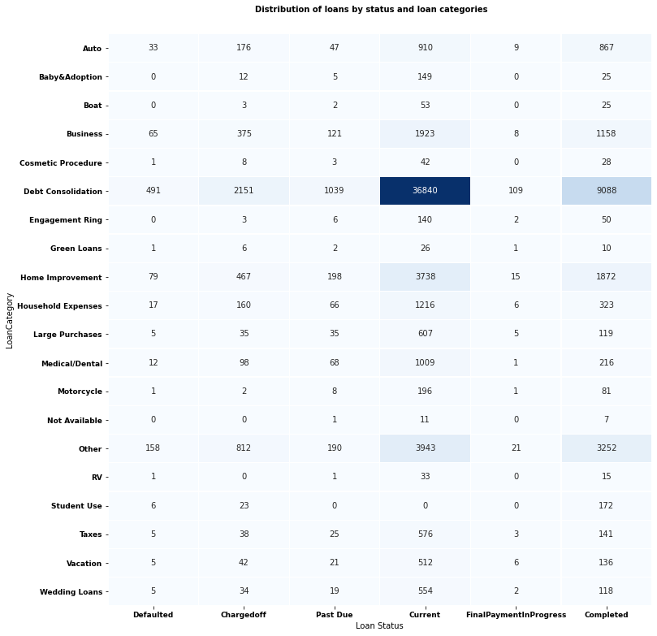

```python
# remove categories where loan count is 0:
loans_except_cancelled.LoanCategory.cat.remove_unused_categories(inplace=True)
# create counts for each loan category
category_counts = loans_except_cancelled.groupby(['LoanCategory']).LoanStatusSimplified.value_counts().sort_index()
category_counts = category_counts.unstack()
category_counts.fillna(value=0, inplace=True)

# rearrange the column list for counts dataframe
loan_categories_lst = ['Defaulted', 'Chargedoff','Past Due',
                       'Current', 'FinalPaymentInProgress','Completed']
category_counts = category_counts[loan_categories_lst]

# Drawing a heatmap with the numeric values in each cell
fig4, ax = plt.subplots(figsize=(12, 12))
fig4.subplots_adjust(top=.94)
plt.suptitle('Distribution of loans by status and loan categories', fontsize=10, fontweight='bold')

ax.set_yticklabels(ax.get_yticklabels(), ha="right", fontsize=9, weight='bold')
ax.set_xticklabels(ax.get_xticklabels(), fontsize=9, weight='bold')

#cbar_kws = {'orientation':"horizontal", 'pad':0.05, 'aspect':50}
g = sb.heatmap(category_counts, annot=True, fmt='.0f',
               linewidths=.3, ax=ax, cmap='Blues', cbar=False);
plt.xlabel('Loan Status');
```

### Debt-to-Income Ratio Relationship with Loan Status and Prosper Score

Debt-to-income ratio has much clearer relationship with Prosper Score compared to Loan Status. Therefore debt-to-income ratio may have influence on loan outcome via Prosper Score influence.

> Note: outliers were hidden to make the plot clearer.

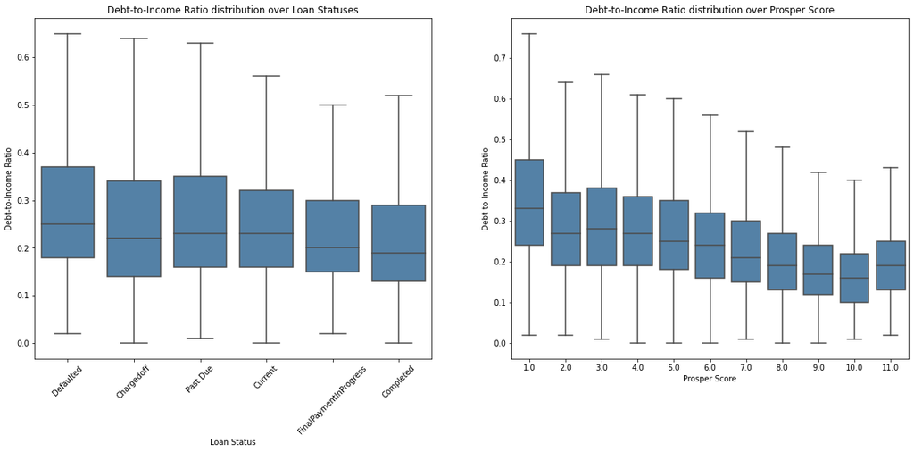

```python
# Debt-to-income distribution in relation to loan outcome and Prosper Rating
plt.figure(figsize = [20, 8])

plt.subplot(1, 2, 1)
sb.boxplot(data=loans_except_cancelled, x='LoanStatusSimplified',
           y='DebtToIncomeRatio', color='steelblue', showfliers=False);
plt.ylabel('Debt-to-Income Ratio')
plt.xlabel('Loan Status')
#plt.yscale('log');
plt.xticks(rotation=45);
plt.title('Debt-to-Income Ratio distribution over Loan Statuses');

plt.subplot(1, 2, 2)
sb.boxplot(data=loans_except_cancelled, x='ProsperScore',
           y='DebtToIncomeRatio', color='steelblue', showfliers=False);
plt.ylabel('Debt-to-Income Ratio')
plt.xlabel('Prosper Score')
#plt.yscale('log');
plt.title('Debt-to-Income Ratio distribution over Prosper Score');
```

### Delinquencies Relationship with Loan Status and Prosper Score

Hence, number of delinquencies over past 7 years can have indirect influence on loan outcome via Prosper Score influence.

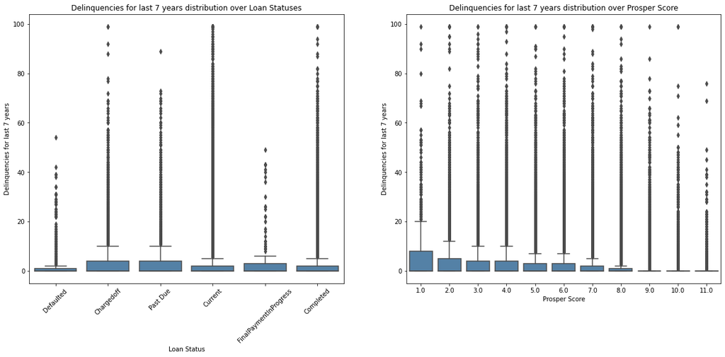

```python
# DelinquenciesLast7Years distribution in relation to loan outcome and Prosper Rating
plt.figure(figsize = [20, 8])

plt.subplot(1, 2, 1)
sb.boxplot(data=loans_except_cancelled, x='LoanStatusSimplified',
           y='DelinquenciesLast7Years', color='steelblue');
plt.xticks(rotation=45);
plt.ylabel('Delinquencies for last 7 years')
plt.xlabel('Loan Status')
plt.title('Delinquencies for last 7 years distribution over Loan Statuses');

plt.subplot(1, 2, 2)
sb.boxplot(data=loans_except_cancelled, x='ProsperScore',
           y='DelinquenciesLast7Years', color='steelblue');
plt.ylabel('Delinquencies for last 7 years')
plt.xlabel('Prosper Score')
plt.title('Delinquencies for last 7 years distribution over Prosper Score');
```

### Bank Card Utilization Relationship with Prosper Rating and Loan Outcome

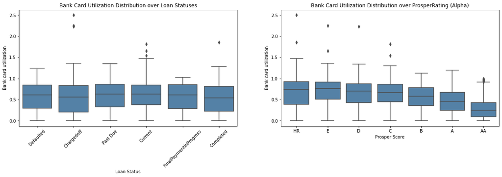

```python
plt.figure(figsize = [20, 5])

plt.subplot(1, 2, 1)
sb.boxplot(data=loans_except_cancelled,
           x='LoanStatusSimplified', y='BankcardUtilization', color='steelblue');
plt.title('Bank Card Utilization Distribution over Loan Statuses');
plt.ylabel('Bank card utilization')
plt.xlabel('Loan Status')
plt.xticks(rotation=45);

plt.subplot(1, 2, 2)
sb.boxplot(data=loans_except_cancelled,
           x='ProsperRating (Alpha)', y='BankcardUtilization', color='steelblue');
plt.title('Bank Card Utilization Distribution over ProsperRating (Alpha)');
plt.ylabel('Bank card utilization')
plt.xlabel('Prosper Score');
```

### Loan Amount and Borrower Rate Interaction with Loan Outcome

There are two interesting interactions:

1. It seems that Prosper lends more money to current loans compared to the past as mean for past due loans is higher for completed loans but lower than for current loans.
2. With regards to relationship between 'BorrowerRate' and loan outcome, we can see that borrower rate on average higher for the loans that defaulted / charged off/ past due compared to current / final payment in progress / completed.

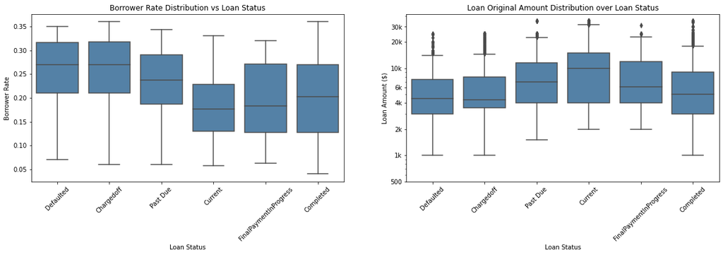

```python
plt.figure(figsize = [20, 5])

plt.subplot(1, 2, 1)
# loan status vs borrower rate box plot
sb.boxplot(data=loans_except_cancelled, x='LoanStatusSimplified',
           y='BorrowerRate', showfliers = True, color='steelblue');
plt.ylabel('Borrower Rate')
plt.xlabel('Loan Status')
plt.title('Borrower Rate Distribution vs Loan Status')
plt.xticks(rotation=45);

plt.subplot(1, 2, 2)
# loan amount distribution plotted on log scale over loan status break down
ax = sb.boxplot(data=loans_except_cancelled,
           x='LoanStatusSimplified', y='LoanOriginalAmount',
           showfliers = True, color='steelblue');
plt.ylabel('Loan Amount ($)')
plt.xlabel('Loan Status')
plt.yscale('log');
ax.set_yticks([500, 1e3 ,2e3, 4e3, 6e3, 1e4, 2e4, 3e4])
ax.set_yticklabels(['500', '1k', '2k', '4k', '6k', '10k', '20k','30k'])
plt.title('Loan Original Amount Distribution over Loan Status' )
plt.xticks(rotation=45);
```

### Stated Monthly Income Relationship with Loan Outcome

As we can see, that current, completed, and loans with final payment in progress have borrowers that stated monthly income is slightly higher than troublesome loans (defaulted, charged off, past due).

However, there is no strong correlation between monthly income and the loan outcome.

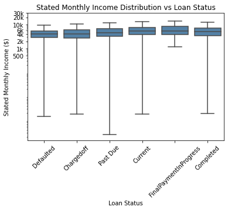

```python
# stated monthly income vs loan outcome
ax = sb.boxplot(data=loans_except_cancelled, x='LoanStatusSimplified',
           y='StatedMonthlyIncome', showfliers = False, color='steelblue');
plt.ylabel('Stated Monthly Income ($)')
plt.xlabel('Loan Status')
plt.yscale('log');
ax.set_yticks([500, 1e3 ,2e3, 4e3, 6e3, 1e4, 2e4, 3e4])
ax.set_yticklabels(['500', '1k', '2k', '4k', '6k', '10k', '20k','30k'])
plt.title('Stated Monthly Income Distribution vs Loan Status')
plt.xticks(rotation=45);
```

### Stated Monthly Income Relationship with Prosper Score and Prosper Rating

> Note: `ProsperScore` is used as numeric variable here to get ProsperScore mean estimation

Stated monthly income has a more clear positive correlation with Prosper Rating (Alpha) compared to Prosper Score.

It can be explained that Prosper Score is calculated by using different set of variables compared to Prosper Rating (Alpha).

Nevertheless, stated monthly income has indirect influence on a loan outcome as it has direct interaction with Prosper Rating.

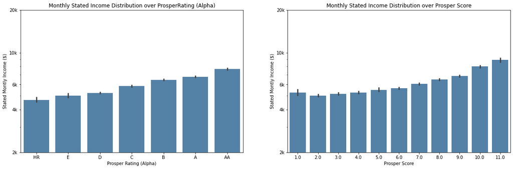

```python
fig, ax = plt.subplots(ncols = 2, figsize = [20,6])

sb.barplot(x='ProsperRating (Alpha)', y="StatedMonthlyIncome",
               data=loans_except_cancelled,
               #palette='vlag_r',
              color='steelblue', ax = ax[0]);
ax[0].set_title('Monthly Stated Income Distribution over ProsperRating (Alpha)')
ax[0].set_ylabel('Stated Montly Income ($)')
ax[0].set_xlabel('Prosper Rating (Alpha)')
ax[0].set_yscale('log')
ax[0].set_yticks([2e3, 4e3, 6e3, 1e4, 2e4])
ax[0].set_yticklabels(['2k', '4k', '6k', '10k','20k'])
ax[0].set_yticklabels([],minor = True);

sb.barplot(x='ProsperScore', y="StatedMonthlyIncome",
            data=loans_except_cancelled,
               #palette='vlag_r',
              color='steelblue', ax = ax[1]);
ax[1].set_title('Monthly Stated Income Distribution over Prosper Score')
ax[1].set_ylabel('Stated Montly Income ($)')
ax[1].set_xlabel('Prosper Score')
ax[1].set_yscale('log')
ax[1].set_yticks([2e3, 4e3, 6e3, 1e4, 2e4])
ax[1].set_yticklabels(['2k', '4k', '6k', '10k','20k'])
ax[1].set_yticklabels([],minor = True);
```

### Employment Status Interaction with Prosper Score and Prosper Rating

Interestingly, self-employed borrowers have lowest Prosper score, however, Prosper rating is lowest for part-time borrowers.

> Note: Prosper Rating (numeric) was used here instead of Prosper rating (Alpha).

As Employment Status interacts with both Prosper Score and Prosper Rating, it can indirectly impact loan outcome.

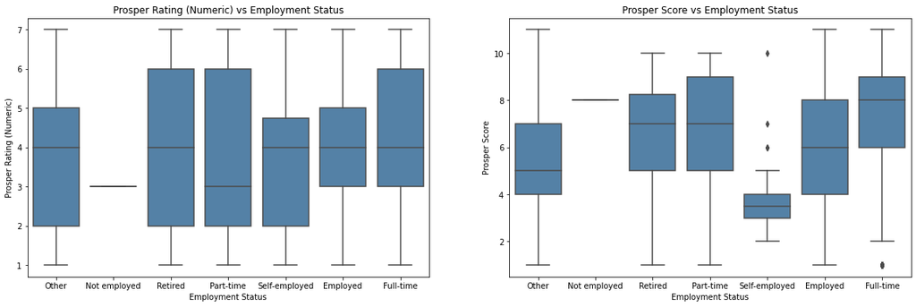

```python
fig, ax = plt.subplots(ncols = 2, figsize = [20,6])

sb.boxplot(y='ProsperRating (numeric)', x="EmploymentStatus",
               data=loans_except_cancelled,
              color='steelblue', ax = ax[0]);
ax[0].set_title('Prosper Rating (Numeric) vs Employment Status')
ax[0].set_xlabel('Employment Status')
ax[0].set_ylabel('Prosper Rating (Numeric)');

sb.boxplot(x='EmploymentStatus', y="ProsperScore",
            data=loans_except_cancelled,
            color='steelblue', ax = ax[1]);
ax[1].set_title('Prosper Score vs Employment Status')
ax[1].set_ylabel('Prosper Score')
ax[1].set_xlabel('Employment Status');
```

## Multivariate Exploration

> Now I will move to exploration of how loan rating, Prosper score and Prosper rating are related to the loan outcome in conjunction with other variables that we saw related to the loan outcome:
> - numerical variables:
>   - stated monthly income
>   - borrower rate
>   - loan originating amount
>   - debt-to-income ratio
> - categorical variables:
>   - loan category
>   - employment status

### Prosper Score and Prosper Rating Consistency

Firstly let's have a look how consistent ratings and scores among all loan outcomes.

> `ProsperRating (Alpha)` and `ProsperScore` look correlated and consistent across all loan statuses, however it cannot be treated as one-to-one mapping as there is a range of scores for a loan rating value.

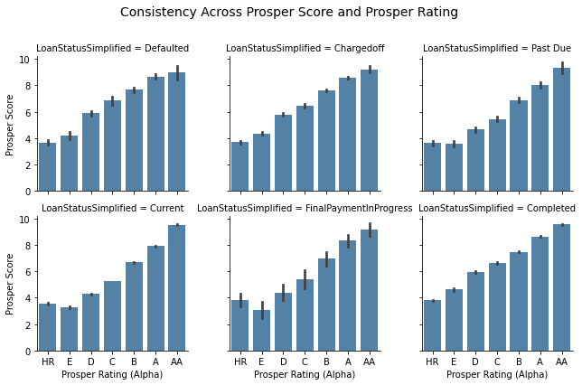

```python
# correlation between prosper score and loan rating - mean estimation
loan_ratings = ['HR','E','D','C','B','A','AA']

g = sb.FacetGrid(data = loans_except_cancelled, col = 'LoanStatusSimplified',#, row = 'ProsperScore',
                 height = 3, margin_titles = False, col_wrap = 3)

g.map(sb.barplot, 'ProsperRating (Alpha)', 'ProsperScore', order = loan_ratings,
      color='steelblue')
g.fig.subplots_adjust(top=0.85)
g.fig.suptitle('Consistency Across Prosper Score and Prosper Rating',
              fontsize=14);
g.set_xlabels('Prosper Rating (Alpha)')
g.set_ylabels('Prosper Score');
#plt.tight_layout()
#plt.show();
```

### Prosper Score and Prosper Rating Consistency vs Loan Amount

Let's have a look how consistent Prosper Score, Prosper Rating (numeric) in relation with loan original amount:

We can see that `ProsperScore` has more clear relationship with loan originating amount and more clear influence on the loan outcome.

There is also upward trend for loan originating amount for higher `ProsperRating (numeric)` and `ProsperRating (Alpha)` values.

Another interesting observation here is defaulted/charged off/ past due loans have smaller loan amount when rating or prosper score increases, although deviation can be quite large which signaling about uncertainty that larger loan amount is correlated to the loan outcome for the higher rated loans / loans with higher prosper score.

Nevertheless, `ProsperScore` has the clearest influence on loan outcome by loan originating amount.

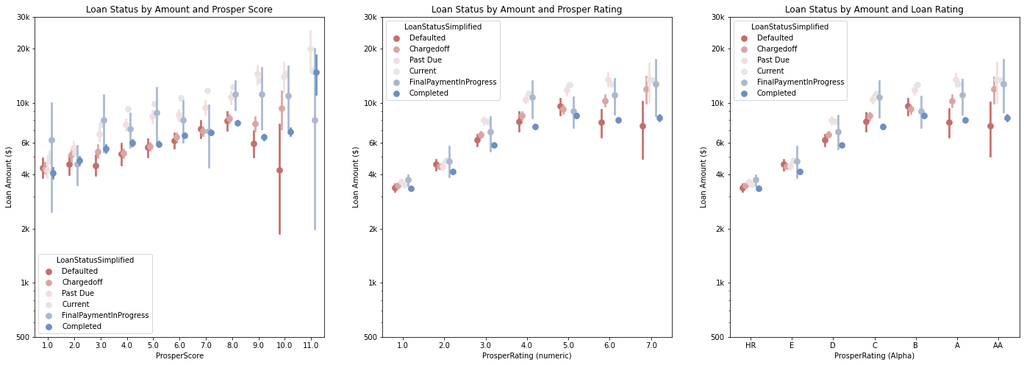

```python
# compare rating and score versus loan originating amount to the loan outcome
fig, ax = plt.subplots(ncols = 3, figsize = [24,8])

sb.pointplot(data = loans_except_cancelled, hue = 'LoanStatusSimplified',
             y = 'LoanOriginalAmount', x = 'ProsperScore',
           palette = 'vlag_r', linestyles = '', dodge = 0.4, ax = ax[0])
ax[0].set_title('Loan Status by Amount and Prosper Score')
ax[0].set_ylabel('Loan Amount ($)')
ax[0].set_yscale('log')
ax[0].set_yticks([500, 1e3 ,2e3, 4e3, 6e3, 1e4, 2e4, 3e4])
ax[0].set_yticklabels(['500', '1k', '2k', '4k', '6k', '10k', '20k','30k'])
ax[0].set_yticklabels([],minor = True)

sb.pointplot(data = loans_except_cancelled, hue = 'LoanStatusSimplified',
             y = 'LoanOriginalAmount', x = 'ProsperRating (numeric)',
           palette = 'vlag_r', linestyles = '', dodge = 0.4, ax = ax[1])
ax[1].set_title('Loan Status by Amount and Prosper Rating')
ax[1].set_ylabel('Loan Amount ($)')
ax[1].set_yscale('log')
ax[1].set_yticks([500, 1e3 ,2e3, 4e3, 6e3, 1e4, 2e4, 3e4])
ax[1].set_yticklabels(['500', '1k', '2k', '4k', '6k', '10k', '20k','30k'])
ax[1].set_yticklabels([],minor = True);

sb.pointplot(data = loans_except_cancelled, hue = 'LoanStatusSimplified',
             y = 'LoanOriginalAmount', x = 'ProsperRating (Alpha)',
           palette = 'vlag_r', linestyles = '', dodge = 0.4, ax = ax[2])
ax[2].set_title('Loan Status by Amount and Loan Rating')
ax[2].set_ylabel('Loan Amount ($)')
ax[2].set_yscale('log')
ax[2].set_yticks([500, 1e3 ,2e3, 4e3, 6e3, 1e4, 2e4, 3e4])
ax[2].set_yticklabels(['500', '1k', '2k', '4k', '6k', '10k', '20k','30k'])
ax[2].set_yticklabels([],minor = True);
```

### Loan Amount and Prosper Score Influence on Loan Outcome

Let's explore how loan amount is distributed on Prosper Score scale among all loan outcomes.

As we can see below, loan distribution among loan rating, loan amount, and prosper score across all loan statuses is highly suggested that:

- `ProsperScore` is correlated to `ProsperRating (Alpha)` and loan originating amount
- loan originating amount is higher for lower rated loans ( rating less than B) when `ProsperScore` is also low (less than 8.0)
- loan amount distribution is wider and higher and moving towards higher loan rating (B, A, AA)for the loans with high `ProsperScore` > 8.0

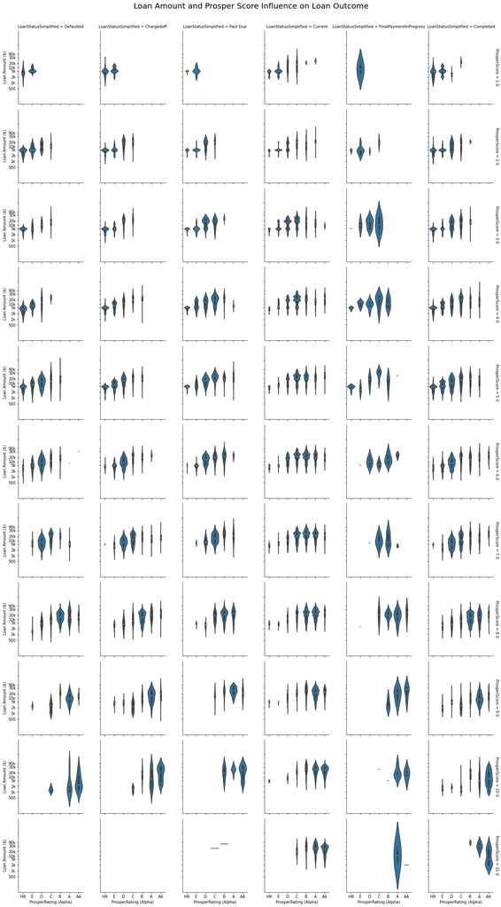

```python
# facet grid to zoom in on loan amount, loan rating, prosper score and loan outcome

prosper_scores = [1.0, 2.0, 3.0, 4.0, 5.0, 6.0, 7.0, 8.0, 9.0, 10.0, 11.0]
g = sb.FacetGrid(data = loans_except_cancelled, col = 'LoanStatusSimplified',
                 row = 'ProsperScore',
                 height = 3, margin_titles = True,
                 row_order = prosper_scores)
g.map(sb.violinplot, 'ProsperRating (Alpha)', 'log_loan_amt', scale='count')
g.fig.subplots_adjust(top=0.95)
g.fig.suptitle('Loan Amount and Prosper Score Influence on Loan Outcome',
              fontsize=20);
g.set_xlabels('ProsperRating (Alpha)')
g.set_ylabels('Loan Amount ($)');
plt.yticks(log_trans(np.array([500, 1e3 ,2e3, 4e3, 6e3, 1e4, 2e4, 3e4,9e4])),
               [500, '1k', '2k', '5k', '10k', '20k', '30k', '90k']);
```

### Stated Monthly Income Influence on Loan Outcome

Next we will explore how stated monthly income can influence loan outcome in conjunction with loan rating or Prosper score.

> This time stated monthly income is more clearly related to Prosper rating than Prosper score as we can see that current, final payment in progress or completed loans have higher stated monthly income on average across all ratings.

> Stated monthly income relationship is not as clear with Prosper Score. However we can see that loans with score 11.0 has no defaulted loans.

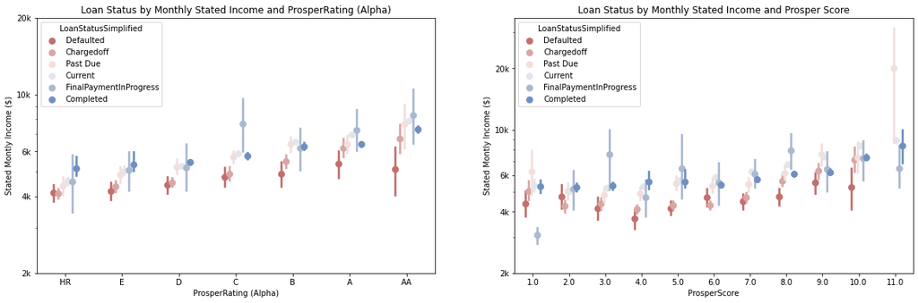

```python
fig, ax = plt.subplots(ncols = 2, figsize = [20,6])

sb.pointplot(data = loans_except_cancelled, hue = 'LoanStatusSimplified',
             y = 'StatedMonthlyIncome', x = 'ProsperRating (Alpha)',
           linestyles = '', dodge = 0.4,
           palette = 'vlag_r', ax = ax[0]);
ax[0].set_title('Loan Status by Monthly Stated Income and ProsperRating (Alpha)')
ax[0].set_ylabel('Stated Montly Income ($)')
ax[0].set_yscale('log')
ax[0].set_yticks([2e3, 4e3, 6e3, 1e4, 2e4])
ax[0].set_yticklabels(['2k', '4k', '6k', '10k','20k'])
ax[0].set_yticklabels([],minor = True);

sb.pointplot(data = loans_except_cancelled, hue = 'LoanStatusSimplified',
             y = 'StatedMonthlyIncome', x = 'ProsperScore',
           linestyles = '', dodge = 0.4,
           palette = 'vlag_r', ax = ax[1]);
ax[1].set_title('Loan Status by Monthly Stated Income and Prosper Score')
ax[1].set_ylabel('Stated Montly Income ($)')
ax[1].set_yscale('log')
ax[1].set_yticks([2e3, 4e3, 6e3, 1e4, 2e4])
ax[1].set_yticklabels(['2k', '4k', '6k', '10k','20k'])
ax[1].set_yticklabels([],minor = True);
```